# Sub-model dredging

Emerald Arthurs and Aidan Brushett

2025-03-29

# 0. Before you begin

Emerald Arthurs M.Sc. Student University of Victoria  
School of Environmental Studies  
Email: emeraldarthurs@uvic.ca

Aidan Brushett M.Sc. Student University of Victoria  
School of Environmental Studies  
Email: aidanbrushett@uvic.ca

# 1. Setup

```r
rm(list = ls())
#library(MASS)
library(glmmTMB)
#library(lme4)
library(tidyverse)
library(MuMIn)
library(rphylopic)
library(corrr)
library(performance)

`%nin%` <- Negate(`%in%`)
```

# 2. Import data

We will also apply standardized z-scaling to the data. This is done *per buffer* since technically they are different datasets.

```r
data <- read_csv("./data/processed/OSM_proportional_weekly_presence_with_covariates_2021_2022_2023.csv")
# OR
data <- read_csv("./data/processed/OSM_proportional_monthly_presence_with_covariates_2021_2022_2023.csv")
# Apply standardized z-scaling to all predictors:
data_scaled <- data %>%

  group_by(buffer_dist) %>%

  mutate(across(harvest:last_col(), ~ as.numeric(scale(.)))) %>%

  ungroup(.)

# The mean will not be perfectly 0 since we grouped the variables by buffer distance to perform the scaling.
summary(data_scaled)
```

```
##     array               site            red_squirrel    absent_red_squirrel
##  Length:8600        Length:8600        Min.   : 0.000   Min.   : 0.000
##  Class :character   Class :character   1st Qu.: 0.000   1st Qu.: 6.000
##  Mode  :character   Mode  :character   Median : 2.000   Median : 9.000
##                                        Mean   : 3.044   Mean   : 8.393
##                                        3rd Qu.: 5.000   3rd Qu.:11.000
##                                        Max.   :15.000   Max.   :15.000
##   buffer_dist      harvest             roads             trails
##  Min.   : 250   Min.   :-0.68275   Min.   :-1.3821   Min.   :-1.0571
##  1st Qu.:1438   1st Qu.:-0.57872   1st Qu.:-0.5958   1st Qu.:-0.6615
##  Median :2625   Median :-0.44888   Median :-0.1568   Median :-0.3234
##  Mean   :2625   Mean   : 0.00000   Mean   : 0.0000   Mean   : 0.0000
##  3rd Qu.:3812   3rd Qu.: 0.03912   3rd Qu.: 0.4968   3rd Qu.: 0.3102
##  Max.   :5000   Max.   : 5.15382   Max.   : 5.1519   Max.   :14.8431
##    veg_edges           wells          lc_grassland     lc_coniferous
##  Min.   :-0.8819   Min.   :-0.7785   Min.   :-1.0569   Min.   :-1.7579
##  1st Qu.:-0.5088   1st Qu.:-0.5940   1st Qu.:-0.7066   1st Qu.:-0.8517
##  Median :-0.1866   Median :-0.3529   Median :-0.2948   Median :-0.1401
##  Mean   : 0.0000   Mean   : 0.0000   Mean   : 0.0000   Mean   : 0.0000
##  3rd Qu.: 0.2057   3rd Qu.: 0.1690   3rd Qu.: 0.3980   3rd Qu.: 0.9257
##  Max.   :13.5328   Max.   : 7.4637   Max.   : 7.6409   Max.   : 1.9159
##   lc_broadleaf        lc_mixed        lc_developed        lc_shrub
##  Min.   :-1.1642   Min.   :-1.0681   Min.   :-1.0301   Min.   :-0.8677
##  1st Qu.:-0.8168   1st Qu.:-0.6964   1st Qu.:-0.9268   1st Qu.:-0.5925
##  Median :-0.3672   Median :-0.3295   Median :-0.1627   Median :-0.4018
##  Mean   : 0.0000   Mean   : 0.0000   Mean   : 0.0000   Mean   : 0.0000
##  3rd Qu.: 0.6766   3rd Qu.: 0.3588   3rd Qu.: 0.4630   3rd Qu.: 0.1504
##  Max.   : 4.2961   Max.   : 5.7323   Max.   : 5.3447   Max.   : 4.2953
##  osm_industrial      natural_cohesion   anthropogenic_cohesion
##  Min.   :-0.514933   Min.   :-17.5055   Min.   :-11.5588
##  1st Qu.:-0.416594   1st Qu.: -0.1082   1st Qu.:  0.1564
##  Median :-0.342112   Median :  0.2729   Median :  0.2162
##  Mean   : 0.000000   Mean   :  0.0000   Mean   :  0.0000
##  3rd Qu.:-0.003209   3rd Qu.:  0.5119   3rd Qu.:  0.2510
##  Max.   :10.659795   Max.   :  0.9048   Max.   :  0.7525
##    natural_ed      anthropogenic_ed   natural_tca      anthropogenic_tca
##  Min.   :-1.1558   Min.   :-1.1530   Min.   :-3.2286   Min.   :-1.1259
##  1st Qu.:-0.5585   1st Qu.:-0.5506   1st Qu.:-0.6653   1st Qu.:-0.7305
##  Median :-0.2848   Median :-0.2814   Median : 0.1245   Median :-0.3289
##  Mean   : 0.0000   Mean   : 0.0000   Mean   : 0.0000   Mean   : 0.0000
```

[output cut: 29 more lines]

```
##  Max.   : 7.3241   Max.   : 5.5493   Max.   : 4.7765   Max.   : 2.08459
##  nonforest_tca     nonveg_anthro_tca  veg_anthro_tca       seismic
##  Min.   :-0.9071   Min.   :-0.48024   Min.   :-0.8690   Min.   :-1.0520
##  1st Qu.:-0.6340   1st Qu.:-0.37691   1st Qu.:-0.6159   1st Qu.:-0.6152
##  Median :-0.4289   Median :-0.29944   Median :-0.4130   Median :-0.3118
##  Mean   : 0.0000   Mean   : 0.00000   Mean   : 0.0000   Mean   : 0.0000
##  3rd Qu.: 0.2283   3rd Qu.:-0.03769   3rd Qu.: 0.1343   3rd Qu.: 0.2410
##  Max.   : 5.2412   Max.   :11.92081   Max.   : 6.2687   Max.   : 5.8230
##    pipe_trans
##  Min.   :-0.9552
##  1st Qu.:-0.7141
##  Median :-0.3276
##  Mean   : 0.0000
##  3rd Qu.: 0.2986
##  Max.   : 7.4237
```

# 3. AIC dredge for sub-models

For the core, disturbance, and configuration models we will run a dredge at each spatial scale and find the most parsimonious model at the best scale for each model type. Then, we’ll choose the overall best model of all spatial scales based on the lowest AIC

## 3.1. ‘NATURAL’ sub-model

For the ‘core’ model (natural features), variables are: conifer forest, broadleaf forest, mixed forest, shrub, and grassland.

- took out broadleaf because correlated

```r
natural_results <- purrr::map_dfr(seq(250, 5000, by = 250), ~{

  cat("\r\r Dredging `NATURAL` sub-models at spatial scale:", .x, "m")

  # Subset the data based on the current buffer distance
  data_subset <- data_scaled %>%

    filter(buffer_dist == .x)

  # Fit the initial model for the current buffer distance
  model_natural <- glmmTMB(cbind(red_squirrel, absent_red_squirrel) ~
                           lc_coniferous +
                           lc_mixed +
                           lc_shrub +
                           lc_grassland +
                           #(1|site) +
                           (1|array),
                         data = data_subset,
                         family = "binomial",
                         na.action = na.fail)

  # Perform dredge selection based on AIC
  dredge_natural <- MuMIn::dredge(model_natural,
                                  rank = AIC,
                                  evaluate = TRUE,
                                  trace = FALSE) %>%

    as.data.frame(.) %>%

    select(-`disp((Int))`) %>%

    rename_with(~ gsub("cond\\(|disp\\(|\\)|\\(", "", .)) %>%

    rename(intercept = `Int`,
           delta_subset = delta) %>%

    mutate(buffer_dist = .x)

  return(dredge_natural)
  }
  ) %>%

  mutate(delta = AIC - min(AIC)) %>%

  arrange(delta)
```

```
##  Dredging `NATURAL` sub-models at spatial scale: 250 m
```

```
##  Dredging `NATURAL` sub-models at spatial scale: 500 m
```

```
##  Dredging `NATURAL` sub-models at spatial scale: 750 m
```

```
##  Dredging `NATURAL` sub-models at spatial scale: 1000 m
```

```
##  Dredging `NATURAL` sub-models at spatial scale: 1250 m
```

```
##  Dredging `NATURAL` sub-models at spatial scale: 1500 m
```

```
##  Dredging `NATURAL` sub-models at spatial scale: 1750 m
```

```
##  Dredging `NATURAL` sub-models at spatial scale: 2000 m
```

```
##  Dredging `NATURAL` sub-models at spatial scale: 2250 m
```

```
##  Dredging `NATURAL` sub-models at spatial scale: 2500 m
```

```
##  Dredging `NATURAL` sub-models at spatial scale: 2750 m
```

```
##  Dredging `NATURAL` sub-models at spatial scale: 3000 m
```

```
##  Dredging `NATURAL` sub-models at spatial scale: 3250 m
```

```
##  Dredging `NATURAL` sub-models at spatial scale: 3500 m
```

```
##  Dredging `NATURAL` sub-models at spatial scale: 3750 m
```

```
##  Dredging `NATURAL` sub-models at spatial scale: 4000 m
```

```
##  Dredging `NATURAL` sub-models at spatial scale: 4250 m
```

```
##  Dredging `NATURAL` sub-models at spatial scale: 4500 m
```

```
##  Dredging `NATURAL` sub-models at spatial scale: 4750 m
```

```
##  Dredging `NATURAL` sub-models at spatial scale: 5000 m
```

```r
head(natural_results)
```

```
##   intercept lc_coniferous lc_grassland  lc_mixed   lc_shrub df    logLik
## 1 -1.189102     0.1286349    0.2158589 0.2143613         NA  5 -1350.084
## 2 -1.189505     0.1672743    0.2250572 0.2338363 0.06185021  6 -1349.116
## 3 -1.188670     0.1027020    0.2024210 0.2459831         NA  5 -1351.303
## 4 -1.188666     0.1211091    0.2064807 0.2557568 0.02830915  6 -1351.113
## 5 -1.182990            NA    0.1901257 0.2218815         NA  4 -1353.904
## 6 -1.181801            NA    0.1988388 0.1866636         NA  4 -1354.290
##        AIC delta_subset     weight buffer_dist      delta
## 1 2710.167   0.00000000 0.49389070         750 0.00000000
## 2 2710.232   0.06460079 0.47819273         750 0.06460079
## 3 2712.606   0.00000000 0.57328730        1000 2.43878044
## 4 2714.226   1.62026065 0.25499824        1000 4.05904110
## 5 2715.808   3.20222322 0.11561612        1000 5.64100366
## 6 2716.581   6.41393176 0.01999232         750 6.41393176
```

What are the top predictors and top spatial scale?

```r
natural_predictors <- natural_results %>%

  select(1:which(names(.) == "df") - 1, -intercept) %>%

  colnames(.)

natural_buffer <- natural_results$buffer_dist[1]

natural_predictors
```

```
## [1] "lc_coniferous" "lc_grassland"  "lc_mixed"      "lc_shrub"
```

```r
natural_buffer
```

```
## [1] 750
```

## 3.2. ‘COMP’ sub-model

For the ‘disturbance’ model (anthropogenic features), variables are: seismic lines, linear (transmission and pipelines), roads, harvest blocks, well pads, and industrial features.

```r
comp_results <- purrr::map_dfr(seq(250, 5000, by = 250), ~{

  cat("\r\r Dredging `COMP` sub-models at spatial scale:", .x, "m")

  # Subset the data based on the current buffer distance
  data_subset <- data_scaled %>%

    filter(buffer_dist == .x)

  # Fit the initial model for the current buffer distance
  model_comp <- glmmTMB(cbind(red_squirrel, absent_red_squirrel) ~
                           harvest +
                           pipe_trans +
                           wells +
                           roads +
                           osm_industrial +
                           seismic +
                           #(1|site) +
                           (1|array),
                         data = data_subset,
                         family = "binomial",
                         na.action = na.fail)


  # Perform dredge selection based on AIC
  dredge_comp <- MuMIn::dredge(model_comp,
                                  rank = AIC,
                                  evaluate = TRUE,
                                  trace = FALSE) %>%

    as.data.frame(.) %>%

    select(-`disp((Int))`) %>%

    rename_with(~ gsub("cond\\(|disp\\(|\\)|\\(", "", .)) %>%

    rename(intercept = `Int`,
           delta_subset = delta) %>%

    mutate(buffer_dist = .x)

  return(dredge_comp)
  }
  ) %>%

  mutate(delta = AIC - min(AIC)) %>%

  arrange(delta)
```

```
##  Dredging `COMP` sub-models at spatial scale: 250 m
```

```
##  Dredging `COMP` sub-models at spatial scale: 500 m
```

```
##  Dredging `COMP` sub-models at spatial scale: 750 m
```

```
##  Dredging `COMP` sub-models at spatial scale: 1000 m
```

```
##  Dredging `COMP` sub-models at spatial scale: 1250 m
```

```
##  Dredging `COMP` sub-models at spatial scale: 1500 m
```

```
##  Dredging `COMP` sub-models at spatial scale: 1750 m
```

```
##  Dredging `COMP` sub-models at spatial scale: 2000 m
```

```
##  Dredging `COMP` sub-models at spatial scale: 2250 m
```

```
##  Dredging `COMP` sub-models at spatial scale: 2500 m
```

```
##  Dredging `COMP` sub-models at spatial scale: 2750 m
```

```
##  Dredging `COMP` sub-models at spatial scale: 3000 m
```

```
##  Dredging `COMP` sub-models at spatial scale: 3250 m
```

```
##  Dredging `COMP` sub-models at spatial scale: 3500 m
```

```
##  Dredging `COMP` sub-models at spatial scale: 3750 m
```

```
##  Dredging `COMP` sub-models at spatial scale: 4000 m
```

```
##  Dredging `COMP` sub-models at spatial scale: 4250 m
```

```
##  Dredging `COMP` sub-models at spatial scale: 4500 m
```

```
##  Dredging `COMP` sub-models at spatial scale: 4750 m
```

```
##  Dredging `COMP` sub-models at spatial scale: 5000 m
```

```r
head(comp_results)
```

```
##   intercept    harvest osm_industrial pipe_trans     roads    seismic
## 1 -1.203807 0.10531265             NA  0.1587624 0.4792497 -0.3003039
## 2 -1.202468 0.09841081    -0.05069539  0.1440341 0.5186993 -0.3004993
## 3 -1.203349 0.09961655             NA  0.1516929 0.4822547 -0.2993023
## 4 -1.201977 0.09245490    -0.04768689  0.1381117 0.5182073 -0.2999425
## 5 -1.203741 0.09229982             NA  0.1578033 0.4791607 -0.2910745
## 6 -1.204628 0.08479229             NA  0.1589099 0.4743322 -0.2825751
##        wells df    logLik      AIC delta_subset    weight buffer_dist     delta
## 1 -0.2307150  7 -1301.086 2616.172    0.0000000 0.3849406        3000 0.0000000
## 2 -0.2361285  8 -1300.243 2616.486    0.3148799 0.3288656        3000 0.3148799
## 3 -0.2395853  7 -1301.324 2616.648    0.0000000 0.3746671        2750 0.4762594
## 4 -0.2446537  8 -1300.552 2617.104    0.4557624 0.2983170        2750 0.9320218
## 5 -0.2492342  7 -1301.621 2617.242    0.0000000 0.3833457        2500 1.0706088
## 6 -0.2566795  7 -1301.669 2617.339    0.0000000 0.3747871        2250 1.1671301
```

What are the top predictors and top spatial scale?

```r
comp_predictors <- comp_results %>%

  select(1:which(names(.) == "df") - 1, -intercept) %>%

  colnames(.)

comp_buffer <- comp_results$buffer_dist[1]

comp_predictors
```

```
## [1] "harvest"        "osm_industrial" "pipe_trans"     "roads"
## [5] "seismic"        "wells"
```

```r
comp_buffer
```

```
## [1] 3000
```

Best model: harvest + linear + wells + roads + seismic (osm_industrial is not a supported covariate)

## 3.3. ‘CONFIG’ sub-model

```r
config_results <- purrr::map_dfr(seq(250, 5000, by = 250), ~{

  cat("\r\r Dredging `CONFIG` sub-models at spatial scale:", .x, "m")

  # Subset the data based on the current buffer distance
  data_subset <- data_scaled %>%

    filter(buffer_dist == .x)

  # Fit the initial model for the current buffer distance
  model_config <- glmmTMB(cbind(red_squirrel, absent_red_squirrel) ~
                           veg_anthro_ed +
                           nonveg_anthro_ed +
                           forest_cai_mn +
                           #forest_tca +
                           #forest_cohesion +
                           #(1|site) +
                           (1|array),
                         data = data_subset,
                         family = "binomial",
                         na.action = na.fail)

  # Perform dredge selection based on AIC
  dredge_config <- MuMIn::dredge(model_config,
                                  rank = AIC,
                                  evaluate = TRUE,
                                  trace = FALSE) %>%

    as.data.frame(.) %>%

    select(-`disp((Int))`) %>%

    rename_with(~ gsub("cond\\(|disp\\(|\\)|\\(", "", .)) %>%

    rename(intercept = `Int`,
           delta_subset = delta) %>%

    mutate(buffer_dist = .x)

  return(dredge_config)
  }
  ) %>%

  mutate(delta = AIC - min(AIC)) %>%

  arrange(delta)
```

```
##  Dredging `CONFIG` sub-models at spatial scale: 250 m
```

```
##  Dredging `CONFIG` sub-models at spatial scale: 500 m
```

```
##  Dredging `CONFIG` sub-models at spatial scale: 750 m
```

```
##  Dredging `CONFIG` sub-models at spatial scale: 1000 m
```

```
##  Dredging `CONFIG` sub-models at spatial scale: 1250 m
```

```
##  Dredging `CONFIG` sub-models at spatial scale: 1500 m
```

```
##  Dredging `CONFIG` sub-models at spatial scale: 1750 m
```

```
##  Dredging `CONFIG` sub-models at spatial scale: 2000 m
```

```
##  Dredging `CONFIG` sub-models at spatial scale: 2250 m
```

```
##  Dredging `CONFIG` sub-models at spatial scale: 2500 m
```

```
##  Dredging `CONFIG` sub-models at spatial scale: 2750 m
```

```
##  Dredging `CONFIG` sub-models at spatial scale: 3000 m
```

```
##  Dredging `CONFIG` sub-models at spatial scale: 3250 m
```

```
##  Dredging `CONFIG` sub-models at spatial scale: 3500 m
```

```
##  Dredging `CONFIG` sub-models at spatial scale: 3750 m
```

```
##  Dredging `CONFIG` sub-models at spatial scale: 4000 m
```

```
##  Dredging `CONFIG` sub-models at spatial scale: 4250 m
```

```
##  Dredging `CONFIG` sub-models at spatial scale: 4500 m
```

```
##  Dredging `CONFIG` sub-models at spatial scale: 4750 m
```

```
##  Dredging `CONFIG` sub-models at spatial scale: 5000 m
```

```r
head(config_results)
```

```
##   intercept forest_cai_mn nonveg_anthro_ed veg_anthro_ed df    logLik      AIC
## 1 -1.183077   -0.12241673        0.4773016    -0.4209547  5 -1307.896 2625.792
## 2 -1.180762            NA        0.4847263    -0.3516172  4 -1309.899 2627.797
## 3 -1.182378   -0.10251913        0.4781786    -0.4024521  5 -1309.354 2628.708
## 4 -1.179427            NA        0.4819030    -0.3522062  4 -1310.573 2629.145
## 5 -1.179755   -0.07399384        0.4777399    -0.4001166  5 -1309.601 2629.202
## 6 -1.181495            NA        0.4831405    -0.3459368  4 -1310.638 2629.277
##   delta_subset    weight buffer_dist    delta
## 1    0.0000000 0.8510164        4000 0.000000
## 2    0.0000000 0.7078247        4250 2.005949
## 3    0.0000000 0.6978583        3750 2.916873
## 4    0.0000000 0.5070973        4500 3.353494
## 5    0.0567823 0.4929027        4500 3.410277
## 6    3.4851896 0.1489836        4000 3.485190
```

What are the top predictors and top spatial scale?

```r
config_predictors <- config_results %>%

  select(1:which(names(.) == "df") - 1, -intercept) %>%

  colnames(.)

config_buffer <- config_results$buffer_dist[1]

config_predictors
```

```
## [1] "forest_cai_mn"    "nonveg_anthro_ed" "veg_anthro_ed"
```

```r
config_buffer
```

```
## [1] 4000
```

## 3.4. Save results

We will save the top predictors and the top spatial scale so that we don’t need to re-run the dredge every time.

```r
save(config_results, comp_results, natural_results,
     comp_predictors, comp_buffer, natural_predictors,
     natural_buffer, config_predictors, config_buffer,
     file = "./data/processed/submodel_dredge_top_predictors_scales.RData")
```

# 4. Scale analysis

Another nice way to visualize our results for the scale analysis is to plot the model weight for the global sub-models at each scale.

Natural sub-model:

```r
natural_scale <- purrr::map(seq(250, 5000, by = 250), ~{

  # Subset the data based on the current buffer distance
  data_subset <- data_scaled %>%

    filter(buffer_dist == .x)

  # Fit the initial model for the current buffer distance
  model_natural <- glmmTMB(cbind(red_squirrel, absent_red_squirrel) ~
                           lc_coniferous +
                           lc_mixed +
                           lc_shrub +
                           lc_grassland +
                           #(1|site) +
                           (1|array),
                         data = data_subset,
                         family = "binomial",
                         na.action = na.fail)

  return(model_natural)
  }
  ) %>%

  set_names(as.character(seq(250, 5000, by = 250))) %>%

  MuMIn::model.sel(.) %>%

  mutate(buffer = as.numeric(rownames(.)),
         submodel = "NATURAL")
```

Anthro composition submodel:

```r
comp_scale <- purrr::map(seq(250, 5000, by = 250), ~{

  # Subset the data based on the current buffer distance
  data_subset <- data_scaled %>%

    filter(buffer_dist == .x)

  # Fit the initial model for the current buffer distance
  model_comp <- glmmTMB(cbind(red_squirrel, absent_red_squirrel) ~
                           harvest +
                           pipe_trans +
                           wells +
                           roads +
                           osm_industrial +
                           seismic +
                           #(1|site) +
                           (1|array),
                         data = data_subset,
                         family = "binomial",
                         na.action = na.fail)

  return(model_comp)
  }
  ) %>%

  set_names(as.character(seq(250, 5000, by = 250))) %>%

  MuMIn::model.sel(.) %>%

  mutate(buffer = as.numeric(rownames(.)),
         submodel = "COMPOSITION")
```

Configuration sub-model:

```r
config_scale <- purrr::map(seq(250, 5000, by = 250), ~{

  # Subset the data based on the current buffer distance
  data_subset <- data_scaled %>%

    filter(buffer_dist == .x)

  # Fit the initial model for the current buffer distance
  model_config <- glmmTMB(cbind(red_squirrel, absent_red_squirrel) ~
                           veg_anthro_ed +
                           nonveg_anthro_ed +
                           forest_cai_mn +
                           #forest_tca +
                           #forest_cohesion +
                           #(1|site) +
                           (1|array),
                         data = data_subset,
                         family = "binomial",
                         na.action = na.fail)

  return(model_config)
  }
  ) %>%

  set_names(as.character(seq(250, 5000, by = 250))) %>%

  MuMIn::model.sel(.) %>%

  mutate(buffer = as.numeric(rownames(.)),
         submodel = "CONFIGURATION")
```

Let’s put it all together into a plot:

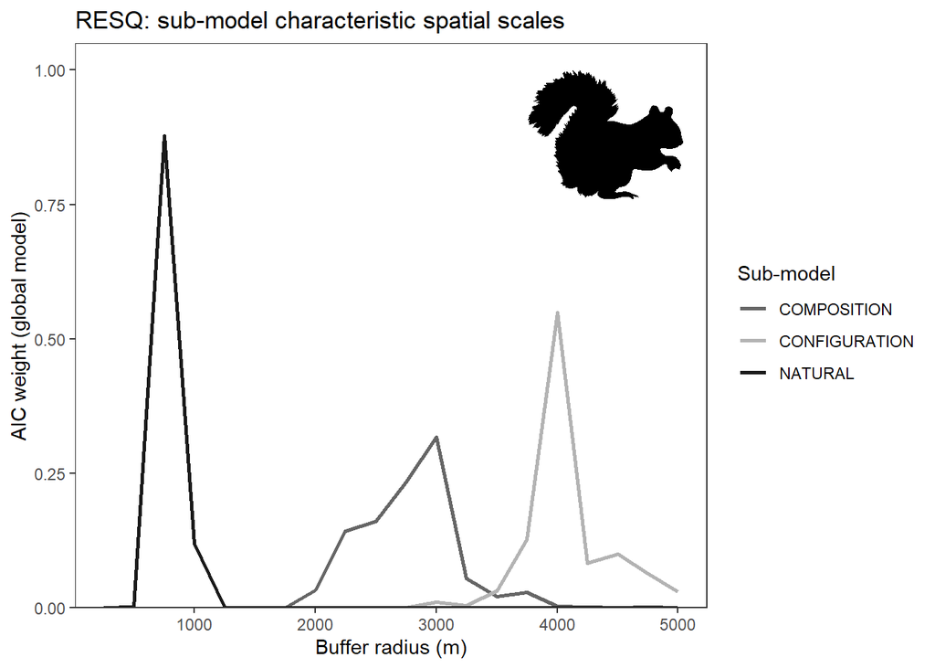

```r
fig_scale <- bind_rows(natural_scale,
                              comp_scale,
                              config_scale) %>%

  ggplot(., aes(x = buffer, y = weight, color = submodel)) +

    geom_line(size = 1) +

    scale_color_manual(values =c("#D24D57",
                                 "#1976D2",
                                 "#388E3C")) +

    scale_color_manual(values =c("grey40","grey70","grey10")) +
    #scale_color_viridis_d() +

    theme_bw() +

    scale_y_continuous(limits = c(0, 1), expand = expansion(add = c(0, 0.05))) +

    labs(x = "Buffer radius (m)",
         y = "AIC weight (global model)",
         color = "Sub-model",
         title = "RESQ: sub-model characteristic spatial scales") +

    # Remove all grid lines
    theme(panel.grid = element_blank()) +

    add_phylopic(
      uuid = get_uuid(name = "Sciurus vulgaris"),
      x = 4400,
      y = 0.88,
      height = 0.24
      )
fig_scale
```

```r
ggsave("./figures/redsquirrel_submodel_scale_modelweight.png", width = 7, height = 4, dpi = 500)
```

Clean up a bit:

```r
rm(comp_scale, config_scale, natural_scale, data_subset, img, uuid, model_config)
```

# 5. Fit full models

## 5.0. Load the dredge results

If the dredge was run in a previous session, you can re-load the results here to save some time:

```r
load("./data/processed/submodel_dredge_top_predictors_scales.RData")
```

## 5.1. Construct and inspect the final dataset

We will pull out the predictors from the submodels **at the appropriate spatial scales** and merge this into one big dataset for final models.

```r
data_final_scaled <- bind_cols(

  # response variables
  data_scaled %>%
    select(1:4) %>%
    distinct(.),

  # natural data
  data_scaled %>%
    filter(buffer_dist == natural_buffer) %>%
    select(natural_predictors) %>%
    mutate(NATURAL_buffer = natural_buffer), # won't use this column, just keeping track of the scale somehow

  # composition data
  data_scaled %>%
    filter(buffer_dist == comp_buffer) %>%
    select(comp_predictors) %>%
    mutate(COMP_buffer = comp_buffer), # won't use this column, just keeping track of the scale somehow

  # configuration data
  data_scaled %>%
    filter(buffer_dist == config_buffer) %>%
    select(config_predictors) %>%
    mutate(CONFIG_buffer = config_buffer) # won't use this column, just keeping track of the scale somehow
  ) %>%

  relocate(contains("buffer"), .after=("absent_red_squirrel"))
summary(data_final_scaled)
```

```
##     array               site            red_squirrel    absent_red_squirrel
##  Length:430         Length:430         Min.   : 0.000   Min.   : 0.000
##  Class :character   Class :character   1st Qu.: 0.000   1st Qu.: 6.000
##  Mode  :character   Mode  :character   Median : 2.000   Median : 9.000
##                                        Mean   : 3.044   Mean   : 8.393
##                                        3rd Qu.: 5.000   3rd Qu.:11.000
##                                        Max.   :15.000   Max.   :15.000
##  NATURAL_buffer  COMP_buffer   CONFIG_buffer  lc_coniferous
##  Min.   :750    Min.   :3000   Min.   :4000   Min.   :-1.4952
##  1st Qu.:750    1st Qu.:3000   1st Qu.:4000   1st Qu.:-0.8956
##  Median :750    Median :3000   Median :4000   Median :-0.1001
##  Mean   :750    Mean   :3000   Mean   :4000   Mean   : 0.0000
##  3rd Qu.:750    3rd Qu.:3000   3rd Qu.:4000   3rd Qu.: 0.9554
##  Max.   :750    Max.   :3000   Max.   :4000   Max.   : 1.6746
##   lc_grassland        lc_mixed          lc_shrub          harvest
##  Min.   :-0.6428   Min.   :-0.7389   Min.   :-0.6145   Min.   :-0.6050
##  1st Qu.:-0.6428   1st Qu.:-0.7389   1st Qu.:-0.6145   1st Qu.:-0.6050
##  Median :-0.6168   Median :-0.4178   Median :-0.4483   Median :-0.4981
##  Mean   : 0.0000   Mean   : 0.0000   Mean   : 0.0000   Mean   : 0.0000
##  3rd Qu.: 0.3901   3rd Qu.: 0.4500   3rd Qu.: 0.1002   3rd Qu.: 0.1166
##  Max.   : 6.8854   Max.   : 5.6700   Max.   : 4.0405   Max.   : 4.8888
##  osm_industrial      pipe_trans          roads            seismic
##  Min.   :-0.4501   Min.   :-0.8423   Min.   :-1.1552   Min.   :-0.9571
##  1st Qu.:-0.4215   1st Qu.:-0.8423   1st Qu.:-0.5669   1st Qu.:-0.5881
##  Median :-0.3309   Median :-0.2990   Median :-0.2250   Median :-0.3079
##  Mean   : 0.0000   Mean   : 0.0000   Mean   : 0.0000   Mean   : 0.0000
##  3rd Qu.: 0.0611   3rd Qu.: 0.3167   3rd Qu.: 0.4982   3rd Qu.: 0.2035
##  Max.   :10.3428   Max.   : 4.5507   Max.   : 5.0868   Max.   : 5.0779
##      wells         forest_cai_mn      nonveg_anthro_ed  veg_anthro_ed
##  Min.   :-0.6949   Min.   :-2.35145   Min.   :-1.0636   Min.   :-1.1796
##  1st Qu.:-0.5799   1st Qu.:-0.61055   1st Qu.:-0.7107   1st Qu.:-0.5634
##  Median :-0.3454   Median : 0.09288   Median :-0.2085   Median :-0.2831
##  Mean   : 0.0000   Mean   : 0.00000   Mean   : 0.0000   Mean   : 0.0000
##  3rd Qu.: 0.1681   3rd Qu.: 0.64875   3rd Qu.: 0.4753   3rd Qu.: 0.2700
##  Max.   : 6.2966   Max.   : 3.72246   Max.   : 5.3359   Max.   : 4.7300
```

Let’s look at the correlation among this final set of candidate variables at their respective spatial scales:

```r
data_final_corr <- data_final_scaled %>%

  select(8:ncol(.)) %>%

  corrr::correlate(., use = "pairwise.complete.obs",
                                           method = "pearson",
                                           diagonal = NA,
                                           quiet = TRUE) %>%
  as_tibble() %>%

  mutate(across(everything(), ~ if_else(row_number() >= min(which(is.na(.))), NA, .))) %>%

  select(rev(names(.))) %>%

  relocate(term) %>%

  pivot_longer(cols = -term, names_to = "var2", values_to = "corr") %>%

  rename(var1 = term) %>%

  arrange(desc(abs(corr))) %>%

  drop_na(.)
head(data_final_corr, 15)
```

```
## # A tibble: 15 × 3
##    var1           var2               corr
##    <chr>          <chr>             <dbl>
##  1 seismic        veg_anthro_ed     0.930
##  2 roads          nonveg_anthro_ed  0.875
##  3 roads          wells             0.719
##  4 wells          nonveg_anthro_ed  0.667
##  5 forest_cai_mn  veg_anthro_ed    -0.639
##  6 pipe_trans     roads             0.632
##  7 pipe_trans     wells             0.558
##  8 wells          veg_anthro_ed     0.509
##  9 pipe_trans     veg_anthro_ed     0.506
## 10 osm_industrial roads             0.500
## 11 seismic        forest_cai_mn    -0.496
## 12 roads          veg_anthro_ed     0.488
## 13 pipe_trans     nonveg_anthro_ed  0.475
## 14 osm_industrial nonveg_anthro_ed  0.436
## 15 lc_coniferous  lc_shrub         -0.408
```

## 5.2. Fit the models

Now let’s fit our models and compete the combination of submodels against each other according to our ecological hypotheses:

```r
# Null model
m_null <- glmmTMB::glmmTMB(cbind(red_squirrel, absent_red_squirrel) ~ 1 +

                     (1|array),
                     data = data_final_scaled,
                     family = "binomial")
```

Recall the natural predictors:

```r
natural_predictors
```

```
## [1] "lc_coniferous" "lc_grassland"  "lc_mixed"      "lc_shrub"
```

Let’s put these into our model:

```r
# Natural model
m_nat <- glmmTMB::glmmTMB(cbind(red_squirrel, absent_red_squirrel) ~

                            # Natural vars
                            lc_coniferous +
                            lc_shrub +
                            lc_grassland +
                            lc_mixed +

                            (1|array),
                            data = data_final_scaled,
                            family = "binomial")
```

Recall the anthropogenic composition predictors:

```r
comp_predictors
```

```
## [1] "harvest"        "osm_industrial" "pipe_trans"     "roads"
## [5] "seismic"        "wells"
```

Let’s put these into our model. Roads and well sites are quite correlated at this scale so we will remove `roads` from the models. There was also weak separation between models with/without `osm_industrial` in the dredging step so we will take this out too.

```r
# Natural + comp model
m_nat_comp <- glmmTMB::glmmTMB(cbind(red_squirrel, absent_red_squirrel) ~

                                 # natural vars
                                 lc_coniferous +
                                 lc_shrub +
                                 lc_grassland +
                                 lc_mixed +

                                 # comp vars
                                 harvest +
                                 pipe_trans +
                                 seismic +
                                 wells +

                                 (1|array),
                                 data = data_final_scaled,
                                 family = "binomial")
```

Recall the configuration predictors:

```r
config_predictors
```

```
## [1] "forest_cai_mn"    "nonveg_anthro_ed" "veg_anthro_ed"
```

```r
# Natural + config model
m_nat_config <- glmmTMB::glmmTMB(cbind(red_squirrel, absent_red_squirrel) ~

                                  # natural vars
                                  lc_coniferous +
                                  lc_shrub +
                                  lc_grassland +
                                  lc_mixed +

                                  # config vars
                                  nonveg_anthro_ed +
                                  veg_anthro_ed +

                                 (1|array),
                                 data = data_final_scaled,
                                 family = "binomial")
```

Our next model will combine as many of these variables as we can into one model without fucked up correlation. Linear anthropogenic features are particularly problematic so we’ll remove them and focus on ‘polygonal’ ones.

```r
# Natural + comp + config model
m_nat_comp_config <- glmmTMB::glmmTMB(cbind(red_squirrel, absent_red_squirrel) ~

                                 # natural vars
                                 lc_coniferous +
                                 lc_shrub +
                                 lc_grassland +
                                 lc_mixed +

                                 # comp vars
                                 harvest +
                                 wells +

                                 # config vars
                                 nonveg_anthro_ed +
                                 veg_anthro_ed +

                                 (1|array),
                                 data = data_final_scaled,
                                 family = "binomial")
```

We’ll also make our final hypotheses here by adding a couple interactions to that model.

```r
# Interaction model 1: do edge effects depend on conifer availability?
m_nat_compXconfig_1 <- glmmTMB::glmmTMB(cbind(red_squirrel, absent_red_squirrel) ~

                                 # natural vars
                                 lc_coniferous +
                                 lc_shrub +
                                 lc_grassland +
                                 lc_mixed +

                                 # comp vars
                                 harvest +
                                 wells +

                                 # config vars
                                 nonveg_anthro_ed +
                                 veg_anthro_ed +

                                 # interactions of interest
                                 lc_coniferous*veg_anthro_ed +

                                 (1|array),
                                 data = data_final_scaled,
                                 family = "binomial")

# Interaction model 2: do edge effects depend on harvest amount?
m_nat_compXconfig_2 <- glmmTMB::glmmTMB(cbind(red_squirrel, absent_red_squirrel) ~

                                 # natural vars
                                 lc_coniferous +
                                 lc_shrub +
                                 lc_grassland +
                                 lc_mixed +

                                 # comp vars
                                 harvest +
                                 wells +

                                 # config vars
                                 nonveg_anthro_ed +
                                 veg_anthro_ed +

                                 # interactions of interest
                                 harvest*veg_anthro_ed +

                                 (1|array),
                                 data = data_final_scaled,
                                 family = "binomial")

# Interaction model 3: custom
#m_nat_compXconfig_3 <- glmmTMB::glmmTMB(cbind(red_squirrel, absent_red_squirrel) ~
#
#                                 # natural vars
#                                 lc_coniferous +
#                                 lc_shrub +
#                                 lc_grassland +
#                                 lc_mixed +
#
#                                 # comp vars
#                                 harvest +
#                                 wells +
#
#                                 # config vars
#                                 nonveg_anthro_ed +
#                                 forest_cohesion +
#
#                                 # interactions of interest
#                                 harvest*forest_cohesion +
#
#                                 (1|array),
#                                 data = data_final_scaled,
#                                 family = "binomial")
```

## 5.3. Perform model selection

Let’s gather all the models into a list and perform model selection:

```r
#rm(m_nat_compXconfig_2)

models <- mget(ls(pattern = "m_"))

models_rank <- MuMIn::model.sel(models) %>%

    as.data.frame(.) %>%

    select(-`disp((Int))`) %>%

    rename_with(~ gsub("cond\\(|disp\\(|\\)|\\(", "", .)) %>%

    rename(intercept = `Int`)

models_rank
```

```
##                     intercept lc_coniferous lc_grassland  lc_mixed   lc_shrub
## m_nat_compXconfig_2 -1.233614     0.2801181    0.2214169 0.2550927 0.12588364
## m_nat_comp_config   -1.216974     0.2720009    0.2147874 0.2618081 0.10677370
## m_nat_compXconfig_1 -1.215405     0.2663739    0.2135004 0.2613265 0.10465751
## m_nat_config        -1.212920     0.2601530    0.1849514 0.2536236 0.08637817
## m_nat_comp          -1.224354     0.1795502    0.1859637 0.2143746 0.04126272
## m_nat               -1.189505     0.1672743    0.2250572 0.2338363 0.06185021
## m_null              -1.162161            NA           NA        NA         NA
##                        harvest pipe_trans   seismic      wells nonveg_anthro_ed
## m_nat_compXconfig_2 0.09435934         NA        NA -0.3552205        0.6600804
## m_nat_comp_config   0.12166747         NA        NA -0.3421425        0.6454279
## m_nat_compXconfig_1 0.11954710         NA        NA -0.3471408        0.6409597
## m_nat_config                NA         NA        NA         NA        0.4804447
## m_nat_comp          0.12523640  0.2181137 -0.304776  0.0497885               NA
## m_nat                       NA         NA        NA         NA               NA
## m_null                      NA         NA        NA         NA               NA
##                     veg_anthro_ed lc_coniferous:veg_anthro_ed
## m_nat_compXconfig_2    -0.4169322                          NA
## m_nat_comp_config      -0.2644986                          NA
## m_nat_compXconfig_1    -0.2413775                 -0.02093346
## m_nat_config           -0.3713599                          NA
## m_nat_comp                     NA                          NA
## m_nat                          NA                          NA
## m_null                         NA                          NA
##                     harvest:veg_anthro_ed df    logLik     AICc     delta
## m_nat_compXconfig_2            -0.3599918 11 -1263.701 2550.033   0.00000
## m_nat_comp_config                      NA 10 -1269.951 2560.427  10.39431
## m_nat_compXconfig_1                    NA 11 -1269.885 2562.402  12.36939
## m_nat_config                           NA  8 -1283.783 2583.909  33.87553
## m_nat_comp                             NA 10 -1312.050 2644.626  94.59265
## m_nat                                  NA  6 -1349.116 2710.430 160.39713
## m_null                                 NA  2 -1377.577 2759.183 209.14947
##                           weight
## m_nat_compXconfig_2 9.924642e-01
## m_nat_comp_config   5.490591e-03
## m_nat_compXconfig_1 2.045198e-03
## m_nat_config        4.372580e-08
## m_nat_comp          2.858793e-21
## m_nat               1.468656e-35
## m_null              3.806145e-46
```

```r
# Fetch the top model
top_model <- get(ls(pattern = rownames(models_rank[1])))
```

## 5.4. Model inspection and validation

### Check out a general summary:

```r
summary(top_model)
```

```
##  Family: binomial  ( logit )
## Formula:
## cbind(red_squirrel, absent_red_squirrel) ~ lc_coniferous + lc_shrub +
##     lc_grassland + lc_mixed + harvest + wells + nonveg_anthro_ed +
##     veg_anthro_ed + harvest * veg_anthro_ed + (1 | array)
## Data: data_final_scaled
##
##      AIC      BIC   logLik deviance df.resid
##   2549.4   2594.1  -1263.7   2527.4      419
##
## Random effects:
##
## Conditional model:
##  Groups Name        Variance Std.Dev.
##  array  (Intercept) 0.4209   0.6488
## Number of obs: 430, groups:  array, 10
##
## Conditional model:
##                       Estimate Std. Error z value Pr(>|z|)
## (Intercept)           -1.23361    0.20889  -5.906 3.51e-09 ***
## lc_coniferous          0.28012    0.05544   5.053 4.35e-07 ***
## lc_shrub               0.12588    0.04672   2.694 0.007053 **
## lc_grassland           0.22142    0.03866   5.727 1.02e-08 ***
## lc_mixed               0.25509    0.05111   4.991 6.01e-07 ***
## harvest                0.09436    0.04653   2.028 0.042584 *
## wells                 -0.35522    0.08198  -4.333 1.47e-05 ***
## nonveg_anthro_ed       0.66008    0.06166  10.704  < 2e-16 ***
## veg_anthro_ed         -0.41693    0.06927  -6.019 1.76e-09 ***
## harvest:veg_anthro_ed -0.35999    0.10285  -3.500 0.000465 ***
## ---
## Signif. codes:  0 '***' 0.001 '**' 0.01 '*' 0.05 '.' 0.1 ' ' 1
```

### Check dispersion:

```r
performance::check_overdispersion(top_model)
```

```
## # Overdispersion test
##
##  dispersion ratio =   2.219
##           p-value = < 0.001
```

```
## Overdispersion detected.
```

The model is overdispersed. Variance is much higher than the mean which violates an assumption of the bernoilli distribution. A zero inflated bernoulli (ZIB) might be more appropriate. Re-binning the data into monthly occurrence frequency might also help eliminate a lot of the zeros that are (likely) the cause of this.

### Check other diagnostics including VIFs.

```r
performance::check_model(top_model)
```

```
## `check_outliers()` does not yet support models of class `glmmTMB`.
```

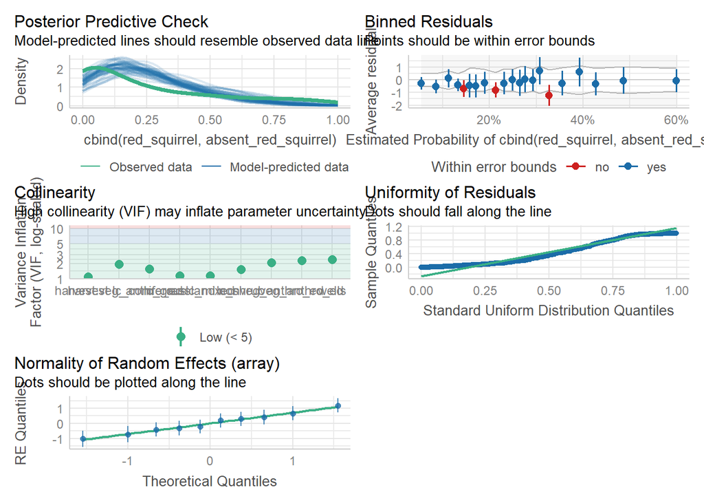

```r
ggsave("./figures/top_model_diagnostics.png", height = 12, width = 9)
```

### Variance inflation factors:

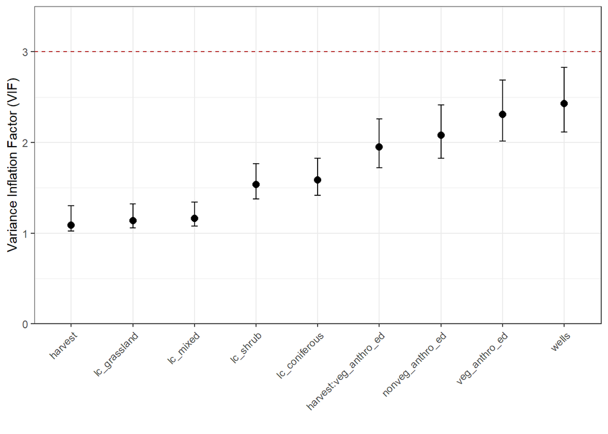

```r
# vif from the car package
performance::check_collinearity(top_model) %>%

  as.data.frame(.) %>%

  # plot with ggplot
  ggplot(aes(x = reorder(Term, VIF), # reorders from smallest VIF to largest (not sure I want like this)
             y = VIF)) +

    geom_hline(yintercept = 3, linetype='dashed', col = 'firebrick') +

    geom_errorbar(aes(ymin = VIF_CI_low, ymax = VIF_CI_high), width = 0.1) +  # Error bars

    # plot as points
    geom_point(size = 2.5) +

    # add labels
    labs(x = '',
         y = 'Variance Inflation Factor (VIF)') +

    scale_y_continuous(limits = c(0, 3.2), expand = expansion(add = c(0, 0.3))) +

    # set theme
    theme_bw() +

    theme(axis.text.x = element_text(angle = 45, hjust = 1))  # Rotate x-axis labels by 45 degrees
```

```r
ggsave("./figures/top_model_VIF.png", dpi=500, width = 5, height = 3.5)
```

## 5.5. Interpret results

```r
summary(top_model)
```

```
##  Family: binomial  ( logit )
## Formula:
## cbind(red_squirrel, absent_red_squirrel) ~ lc_coniferous + lc_shrub +
##     lc_grassland + lc_mixed + harvest + wells + nonveg_anthro_ed +
##     veg_anthro_ed + harvest * veg_anthro_ed + (1 | array)
## Data: data_final_scaled
##
##      AIC      BIC   logLik deviance df.resid
##   2549.4   2594.1  -1263.7   2527.4      419
##
## Random effects:
##
## Conditional model:
##  Groups Name        Variance Std.Dev.
##  array  (Intercept) 0.4209   0.6488
## Number of obs: 430, groups:  array, 10
##
## Conditional model:
##                       Estimate Std. Error z value Pr(>|z|)
## (Intercept)           -1.23361    0.20889  -5.906 3.51e-09 ***
## lc_coniferous          0.28012    0.05544   5.053 4.35e-07 ***
## lc_shrub               0.12588    0.04672   2.694 0.007053 **
## lc_grassland           0.22142    0.03866   5.727 1.02e-08 ***
## lc_mixed               0.25509    0.05111   4.991 6.01e-07 ***
## harvest                0.09436    0.04653   2.028 0.042584 *
## wells                 -0.35522    0.08198  -4.333 1.47e-05 ***
## nonveg_anthro_ed       0.66008    0.06166  10.704  < 2e-16 ***
## veg_anthro_ed         -0.41693    0.06927  -6.019 1.76e-09 ***
## harvest:veg_anthro_ed -0.35999    0.10285  -3.500 0.000465 ***
## ---
## Signif. codes:  0 '***' 0.001 '**' 0.01 '*' 0.05 '.' 0.1 ' ' 1
```

Odds ratio plots for the conditional model:

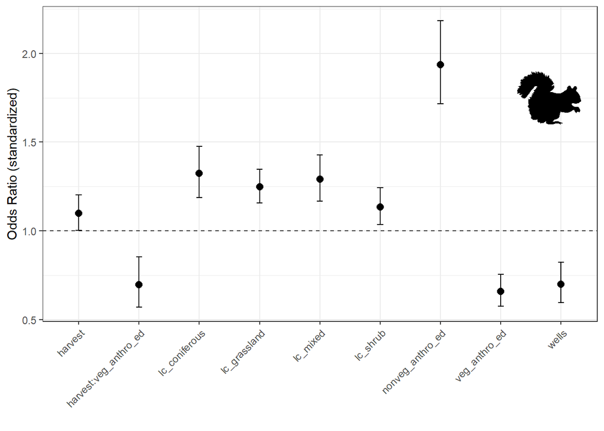

```r
confint(top_model) %>%

  as_tibble(rownames = "term") %>%

  set_names(c('term', 'lower', 'upper', 'estimate')) %>%

  mutate(across(c('lower', 'upper', 'estimate'), exp)) %>%

  filter(term %nin% c('(Intercept)', 'Std.Dev.(Intercept)|array')) %>%

  ggplot(., aes(x = term)) +

    geom_hline(yintercept = 1, linetype='dashed', col = 'grey20') +

    geom_errorbar(aes(x = term, ymin = lower, ymax = upper), width = 0.1) +  # Error bars

    # add labels
    labs(x = '',
         y = 'Odds Ratio (standardized)') +

    # plot as bars
    geom_point(aes(y = estimate), size = 2.5) +

      # set theme
    theme_bw() +

    theme(axis.text.x = element_text(angle = 45, hjust = 1)) +   # Rotate x-axis labels by 45 degrees

    add_phylopic(
      uuid = get_uuid(name = "Sciurus vulgaris"),
      x = 8.8,
      y = 1.75,
      height = 0.3
      )
```

```r
ggsave("./figures/top_model_odds_ratios.png", width = 5, height = 3.5)
```

## 5.6. Plot conditional effects for a fixed effect of interest (no interaction)

[output not shown]

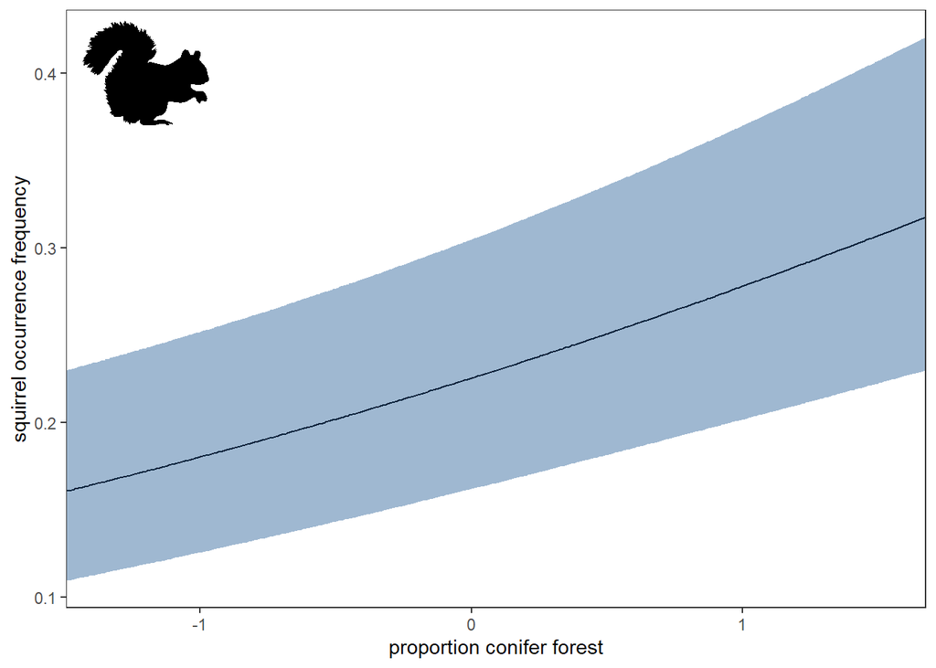

```r
ggeffects::ggpredict(top_model, terms = c("lc_coniferous [all]")) %>%

  ggplot(., aes(x = x, y = predicted)) +

    geom_line(size = 0.5) +  # Set lines to black

    geom_ribbon(aes(ymin = conf.low, ymax = conf.high), alpha = 0.4, fill = 'dodgerblue4') +

    labs(x = "proportion conifer forest",
         y = "squirrel occurrence frequency") +

    scale_x_continuous(expand = c(0, 0)) +  # Remove left blank space

    theme_bw() +

    theme(panel.grid = element_blank()) +

    add_phylopic(
      uuid = get_uuid(name = "Sciurus vulgaris"),
      x = -1.2,
      y = 0.4,
      height = 0.06
      )
```

```r
ggsave("./figures/top_model_conifer.png", dpi=400, width = 6, height = 4)
```

## 5.7. Plot conditional effects for a fixed effect of interest **with** an interaction

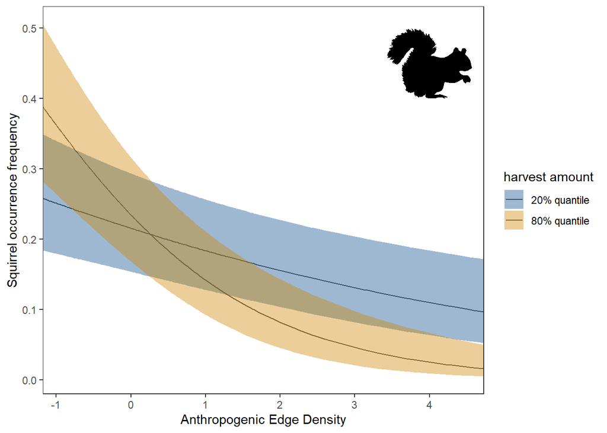

```r
ggeffects::ggpredict(top_model,
                              terms = c("veg_anthro_ed [all]",
                                        paste0("harvest [",
                                               quantile(data_final_scaled$harvest, 0.80),
                                               ", ",
                                               quantile(data_final_scaled$harvest, 0.20),
                                               "]"))) %>%

  ggplot(., aes(x = x, y = predicted, color = group)) +

    geom_line(size = 0.5) +  # Set lines to black
    geom_ribbon(aes(ymin = conf.low, ymax = conf.high, fill = group), alpha = 0.4, color = NA) +

    scale_color_manual(values = c('grey30', 'grey30'), labels = c("20% quantile", "80% quantile")) +  # Keep all lines black

    scale_fill_manual(values = c('dodgerblue4', 'orange3'), labels = c("20% quantile", "80% quantile")) +  # Set colors for ribbons

    labs(x = "Anthropogenic Edge Density",
         y = "Squirrel occurrence frequency",
         color = "harvest amount", fill = "harvest amount") +

    scale_x_continuous(expand = c(0, 0)) +  # Remove left blank space

    theme_bw() +

    theme(panel.grid = element_blank()) +

    add_phylopic(
      uuid = get_uuid(name = "Sciurus vulgaris"),
      x = 4.0,
      y = 0.45,
      height = 0.1
      )
```

```r
ggsave("./figures/top_model_harvest_edge_interaction.png", dpi=400, width = 7, height = 4)
```